# Homework 7

Yuvraj Jain

April 14, 2023

# Instructions

**Exercises:** 1,4 (Pg. 358); 1,4 (Pgs. 371)

**Submission:** Submit via an electronic document on Sakai. Must be submitted as a HTML file generated in RStudio. All assigned problems are chosen according to the textbook *R for Data Science*. You do not need R code to answer every question. If you answer without using R code, delete the code chunk. If the question requires R code, make sure you display R code. If the question requires a figure, make sure you display a figure. A lot of the questions can be answered in written response, but require R code and/or figures for understanding and explaining.

# Chapter 18 (Pg. 358)

## Exercise 1:

Instead of using `lm()` to to fit a straight line, you can `loess()` to fit a smooth curve. Repeat the process of model fitting, grid generation, predictions, and visualization on `sim1` using `loess()` instead of `lm()`. How does the result compare to `geom_smooth()`?

### Model Fitting:

```r
sim1_loess <- loess(y ~ x, data = sim1)
sim1_loess
```

```
## Call:
## loess(formula = y ~ x, data = sim1)
##
## Number of Observations: 30
## Equivalent Number of Parameters: 4.19
## Residual Standard Error: 2.262
```

### Generating Grid:

```r
grid <- sim1 %>%
  data_grid(x)
grid
```

```
## # A tibble: 10 × 1
##        x
##    <int>
##  1     1
##  2     2
##  3     3
##  4     4
##  5     5
##  6     6
##  7     7
##  8     8
##  9     9
## 10    10
```

### Adding Predictions:

```r
grid <- grid %>%
  add_predictions(sim1_loess)
grid
```

```
## # A tibble: 10 × 2
##        x  pred
##    <int> <dbl>
##  1     1  5.34
##  2     2  8.27
##  3     3 10.8
##  4     4 12.8
##  5     5 14.6
##  6     6 16.6
##  7     7 18.7
##  8     8 20.8
##  9     9 22.6
## 10    10 24.0
```

### Visualization:

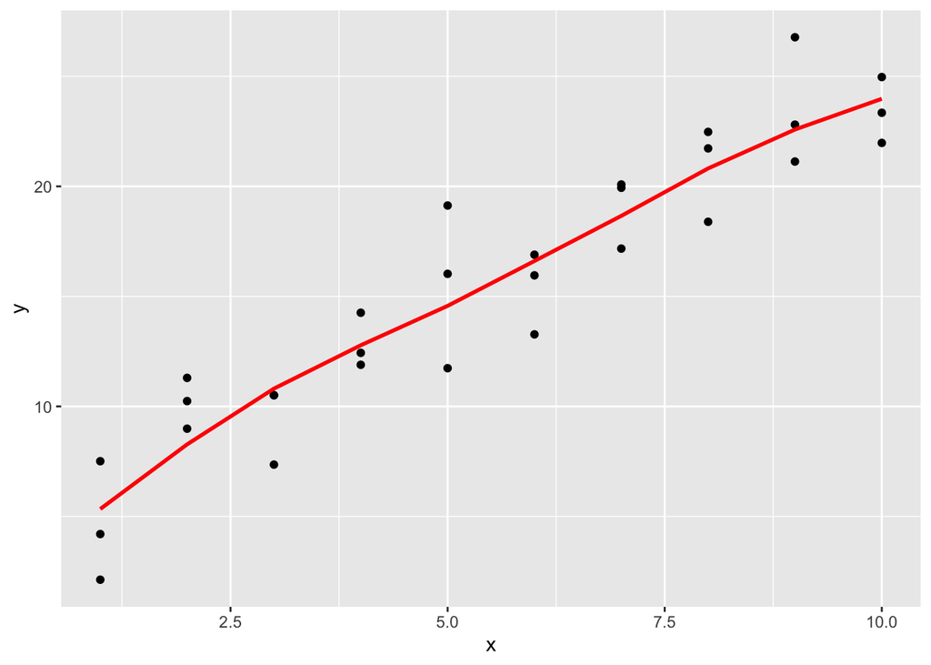

```r
ggplot() +
  geom_point(sim1, mapping = aes(x = x, y = y)) +
  geom_line(
    data = grid,
    mapping = aes(x = x, y = pred),
    color = "red",
    linewidth = 1
  )
```

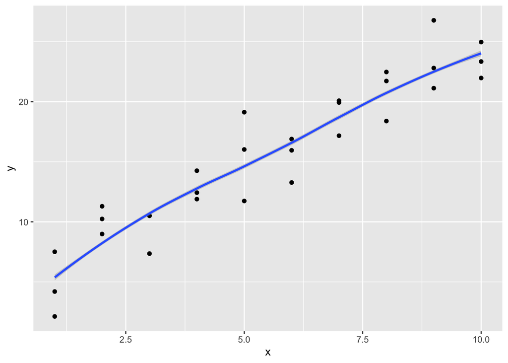

```r
ggplot() +
  geom_point(sim1, mapping = aes(x = x, y = y)) +
  geom_smooth(grid, mapping = aes(x = x, y = pred))
```

## Exercise 4:

Why might you want to look at a frequency polygon of absolute residuals? What are the pros and cons compared to looking at the raw residuals?

### Pros of looking at a frequency polygon of absolute residuals:

- Provides a clearer picture of the overall accuracy of the model.
- Captures the magnitude of errors, allowing us to see if the model is consistently making predictions that are off by a certain amount.
- Helps to identify patterns or trends in the errors, such as over- or under-prediction for certain values.

### Cons of looking at a frequency polygon of absolute residuals:

- Does not provide information about the direction of errors, which may be important in certain contexts.
- Does not allow for the identification of systematic biases, such as a tendency to consistently over- or under-predict values in a certain range.
- May be less intuitive or difficult to interpret.

# Chapter 18 (Pg. 371)

## Exercise 1:

What happens if you repeat the analysis of sim2 using a model without an intercept? What happens to the model equation? What happens to the predictions?

Removing the intercept from our model:

```r
mod2a <- lm(y ~ x - 1, data = sim2)
mod2 <- lm(y ~ x, data = sim2)
```

The predictions are exactly the same in the models with and without an intercept:

```r
grid <- sim2 %>%
  data_grid(x) %>%
  spread_predictions(mod2, mod2a)
grid
```

```
## # A tibble: 4 × 3
##   x      mod2 mod2a
##   <chr> <dbl> <dbl>
## 1 a      1.15  1.15
## 2 b      8.12  8.12
## 3 c      6.13  6.13
## 4 d      1.91  1.91
```

## Exercise 4:

For sim4, which of mod1 and mod2 is better? I think mod2 does a slightly better job at removing patterns, but it’s pretty subtle. Can you come up with a plot to support my claim?

Based on the models `mod1` and `mod2` written in the readings before the exercise, we know that:

```r
mod1 <- lm(y ~ x1 + x2, data = sim4)
mod2 <- lm(y ~ x1 * x2, data = sim4)
sim4_mods <- gather_residuals(sim4, mod1, mod2)
```

I can make a frequency polygon plot for the residuals of mod1 and mod2 to make a more appropriate comparison between the two. Here is the frequency polygon below:

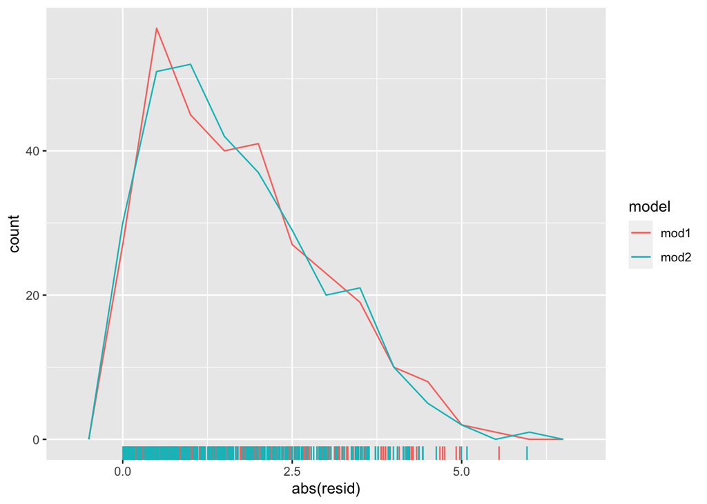

```r
ggplot(sim4_mods, aes(x = abs(resid), color = model)) +
  geom_freqpoly(binwidth = 0.5) +
  geom_rug()
```

From the above plot, we can see that mod2 has slightly lesser residual values than mod1, and this confirms that `mod2` does a slightly better job at removing patterns.